# ggplot-sol

Jose Rojas

2025-07-16

# Solutions

```r
us_data <- filter(gapminder, country == "United States")
```

### Q01. Replicate that scatterplot using ggplot() with a points layer

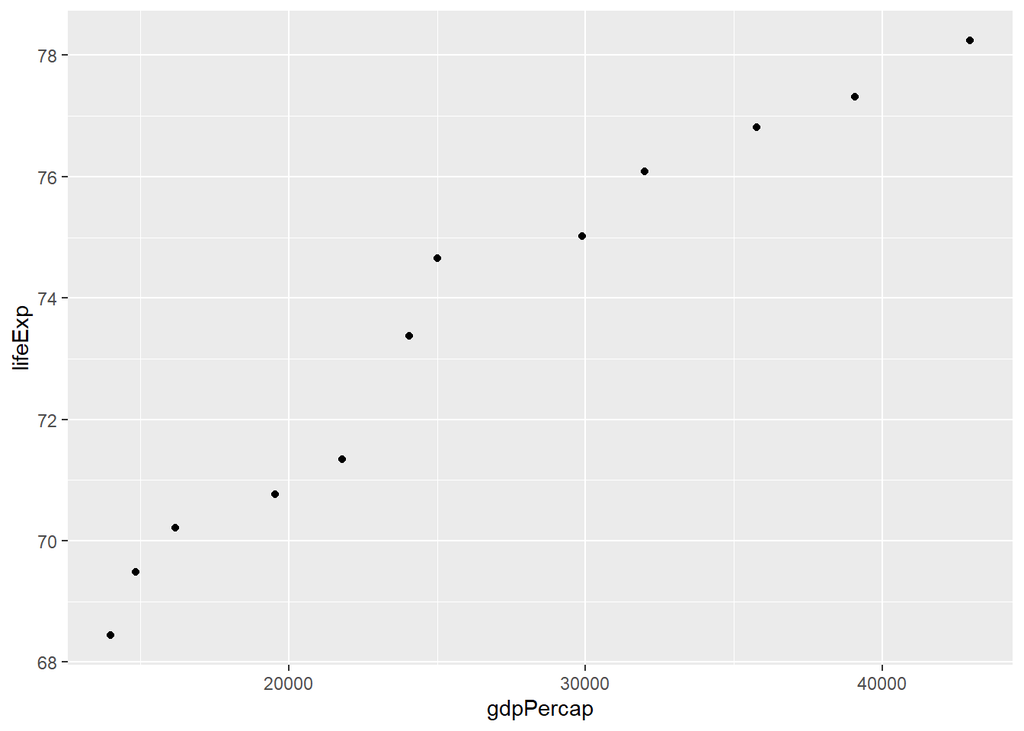

```r
ggplot(data = us_data, aes(x = gdpPercap, y = lifeExp)) +
  geom_point()
```

### Q02. Add a main title and axis labels (labs) to your ggplot

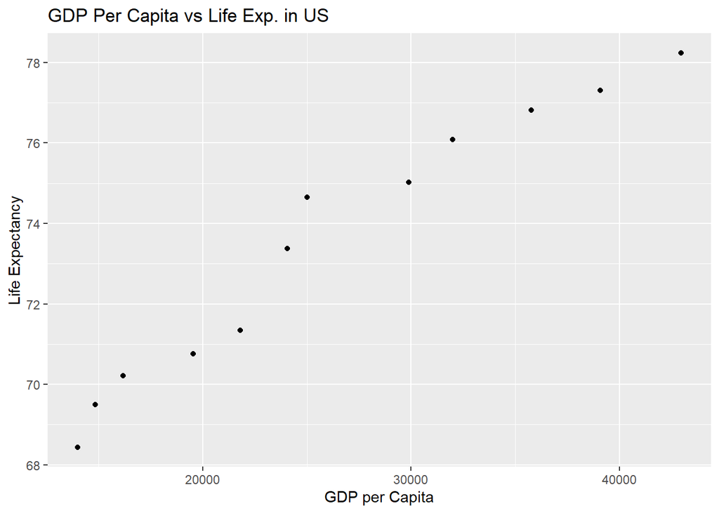

```r
us_data %>%
ggplot(data = ., aes(x = gdpPercap, y = lifeExp)) +
  geom_point() +
  labs(x = "GDP per Capita",
       y = "Life Expectancy",
       title = "GDP Per Capita vs Life Exp. in US")
```

### Q03. Use multiple geom’s in a ggplot (if there’s no blank ’__’, you don’t need to write anything!):

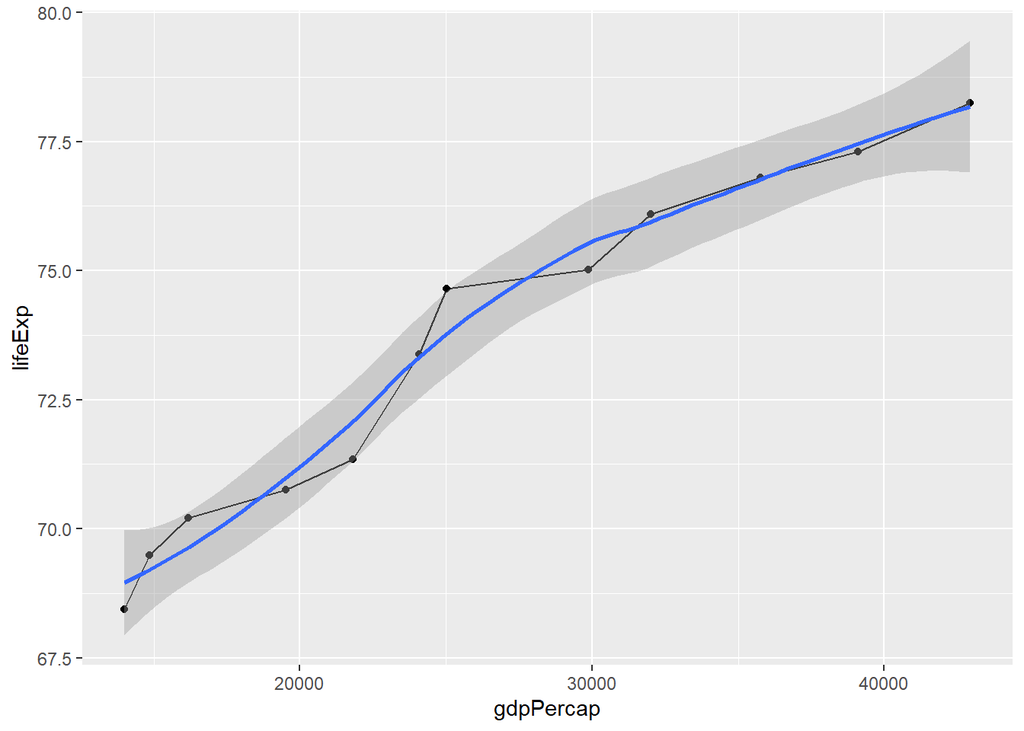

```r
us_data %>%
ggplot(data = ., aes(x = gdpPercap, y = lifeExp)) +
  geom_point() +
  geom_line() +
  geom_smooth()
```

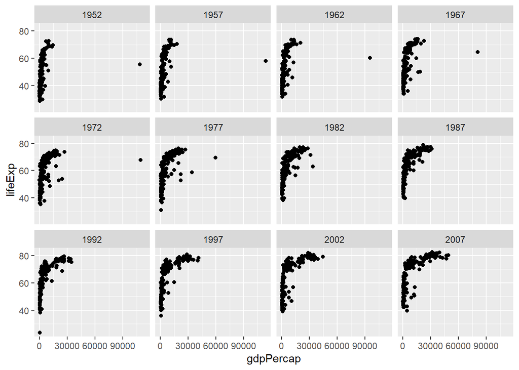

```r
ggplot(data = gapminder, aes(x = gdpPercap, y = lifeExp)) +
  geom_point() +
  facet_wrap(~ year)
```

### Q05. Draw a scatterplot comparing gdpPercap and lifeExp, where different continents are drawn with different colors.

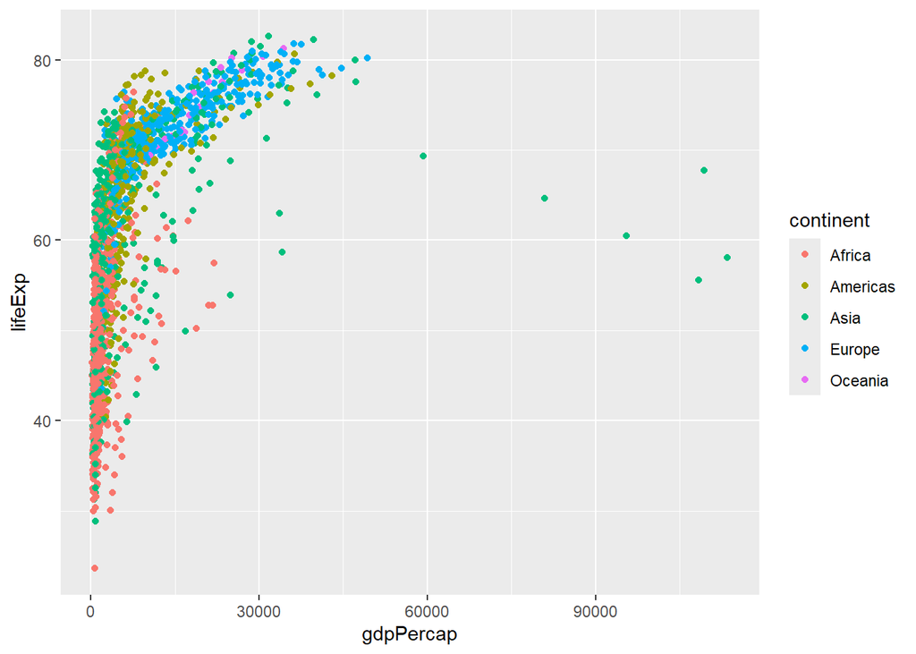

```r
ggplot(data = gapminder, aes(x = gdpPercap, y = lifeExp, color = continent)) +
  geom_point()
```

### Q06. Use ‘color’ to represent ‘continent’, and use ‘fill’ to represent ‘year’.

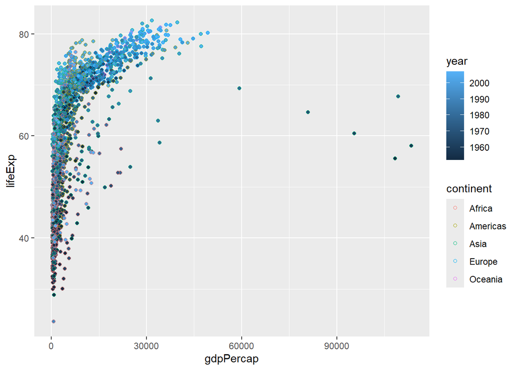

```r
ggplot(
  data = gapminder,
  aes(x = gdpPercap, y = lifeExp, color = continent, fill = year)
  ) +
  geom_point(shape = 21)
```

### Q07. Try mapping ‘shape’ to ‘continent’ *inside* of an aes() call.

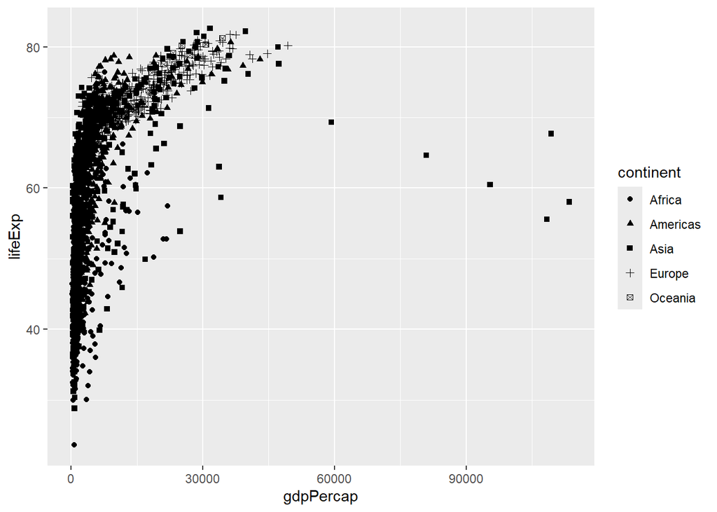

```r
ggplot(data = gapminder, aes(x = gdpPercap, y = lifeExp)) +
  geom_point(aes(shape = continent))
```

### Q08. So far we have 3 aesthetic mappings other than x and y axis:

They are ‘color’, ‘fill’, and ‘shape’. The last ‘aes’ we’ll talk about is ‘size’, which adjusts point size. Add 2 ‘aes’ to this plot: map ‘continent’ to ‘color’, and map ‘pop’ to ‘size’. How many legends are there now?

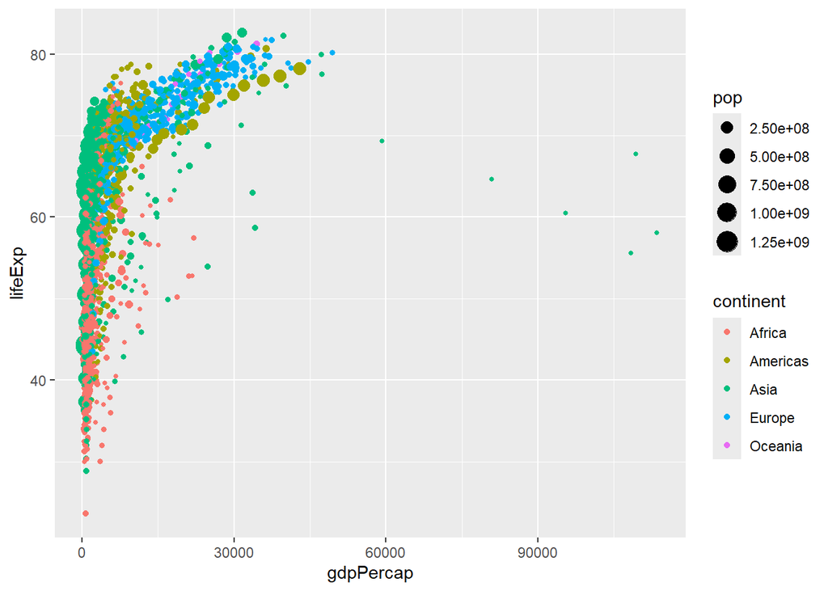

```r
ggplot(data = gapminder, aes(x = gdpPercap, y = lifeExp)) +
  geom_point(aes(color = continent, size = pop))
```

### Q09. Draw a histogram to visualize lifeExp using geom_histogram().

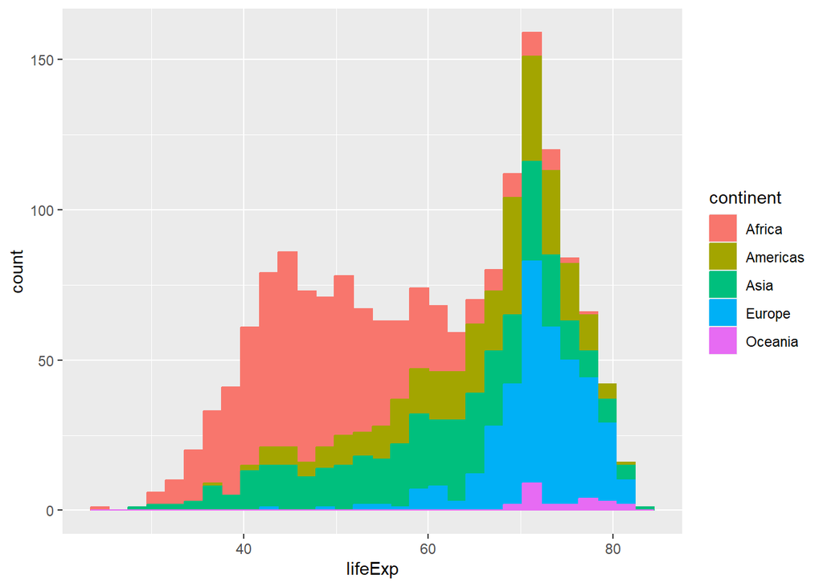

```r
ggplot(
  data = gapminder,
  aes(x = lifeExp, color = continent, fill = continent)
  ) +
  geom_histogram()
```

### Q10. Experiment with different binwidths for your histogram.

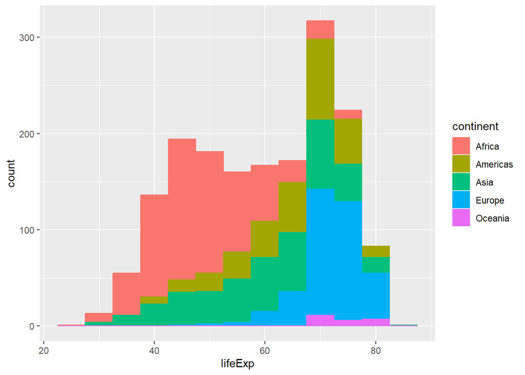

```r
ggplot(
  data = gapminder,
  aes(x = lifeExp, color = continent, fill = continent)
  ) +
  geom_histogram(binwidth = 5)
```

### Q11. geom_freqpoly() is just like a histogram, but it uses lines instead of bars to communicate the number of observations in each bin.

Again, experiment with binwidth.

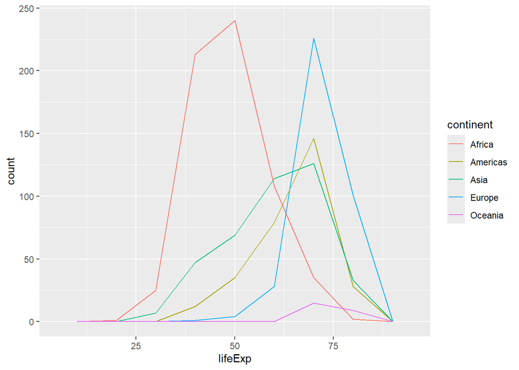

```r
ggplot(
  data = gapminder, aes(x = lifeExp, color = continent)
  ) +
  geom_freqpoly(binwidth = 10)
```

### Q12. Make a filled frequency polygon using an area plot: geom_area().

In the blank, experiment with setting ‘color’ versus ‘fill’ as ‘continent’.

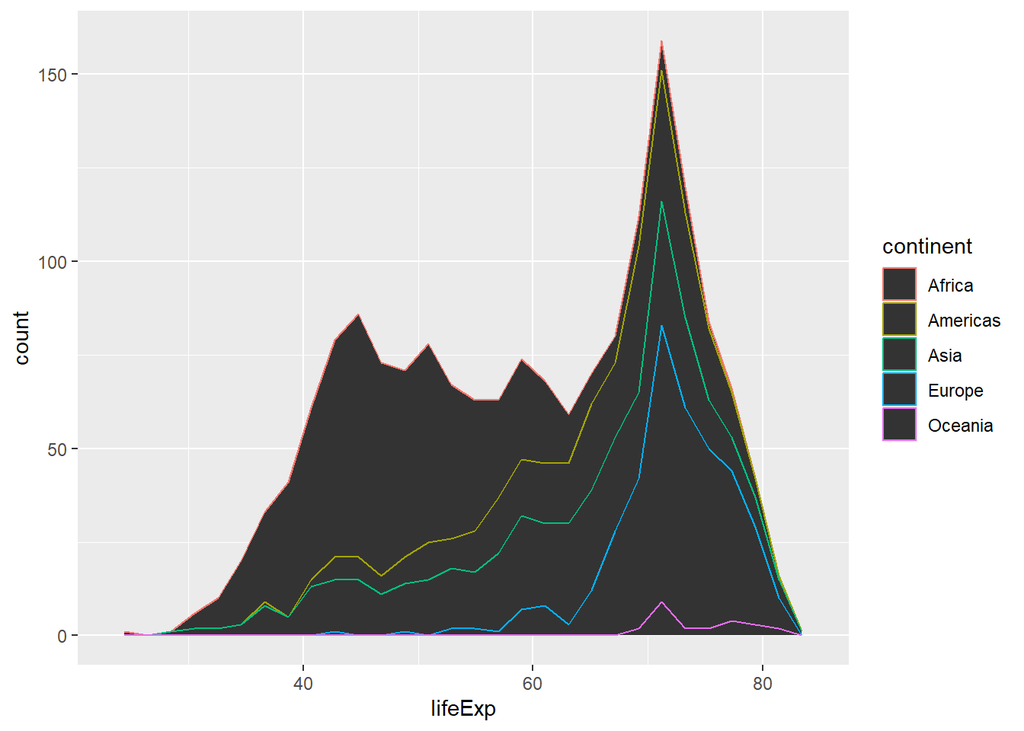

```r
ggplot(data = gapminder, aes(x = lifeExp, color = continent)) +
  geom_area(stat = "bin")
```

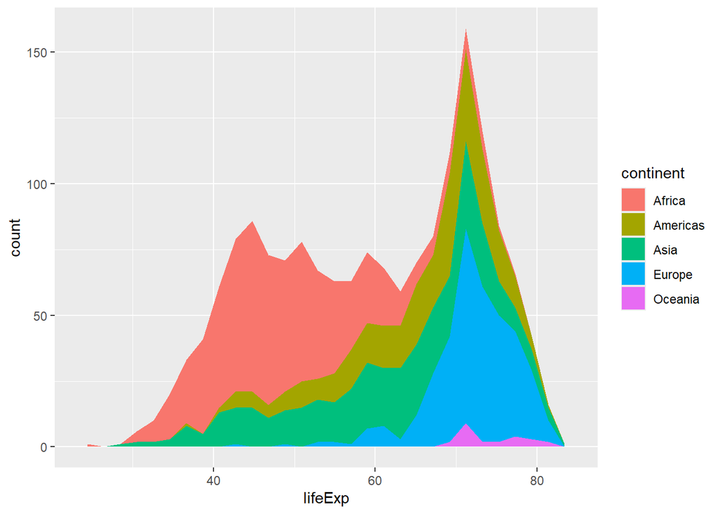

```r
ggplot(data = gapminder, aes(x = lifeExp, fill = continent)) +
  geom_area(stat = "bin")
```

### Q13. Notice that the continents are stacked up on top of each other in the previous plot.

To change that behavior, set position = “dodge”.

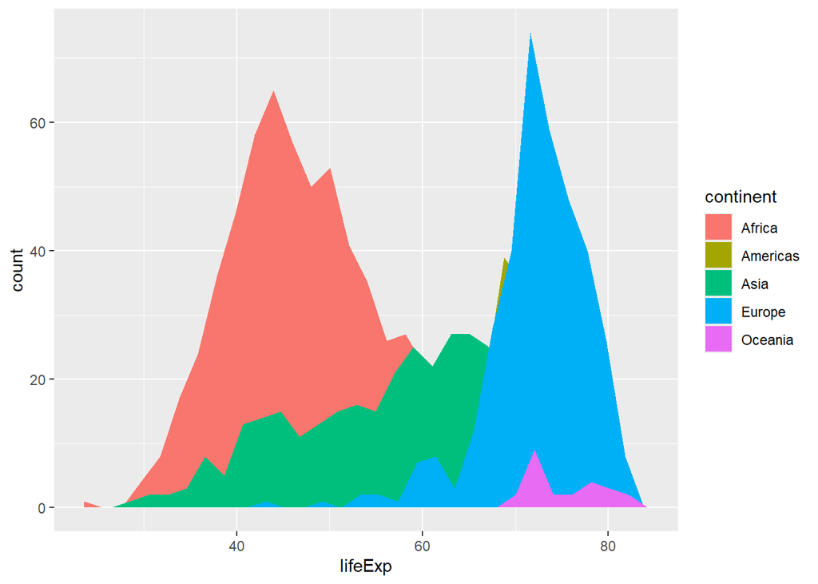

```r
ggplot(data = gapminder, aes(x = lifeExp, fill = continent)) +
  geom_area(stat = "bin", position = 'dodge')
```

Setting ‘alpha = .5’ reduces the ‘geom’ transparency to 50%. Experiment with different alphas.

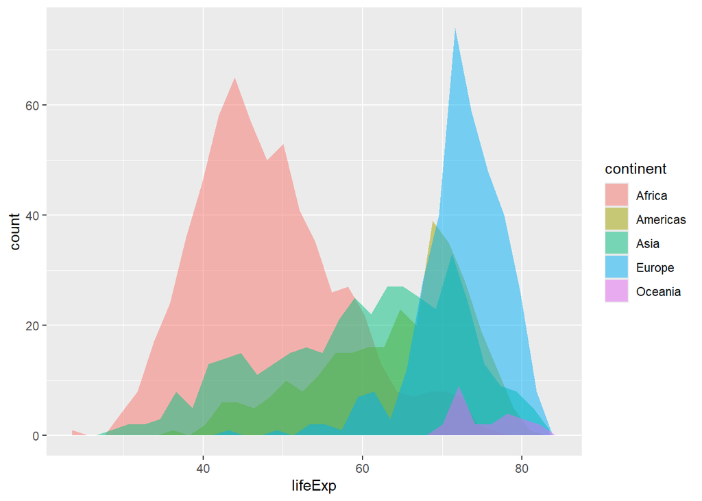

```r
ggplot(data = gapminder, aes(x = lifeExp, fill = continent)) +
  geom_area(stat = "bin", position = "dodge", alpha = 0.5)
```

### Q15. Experiment with setting ‘color’ and ‘fill’ to ‘continent’.

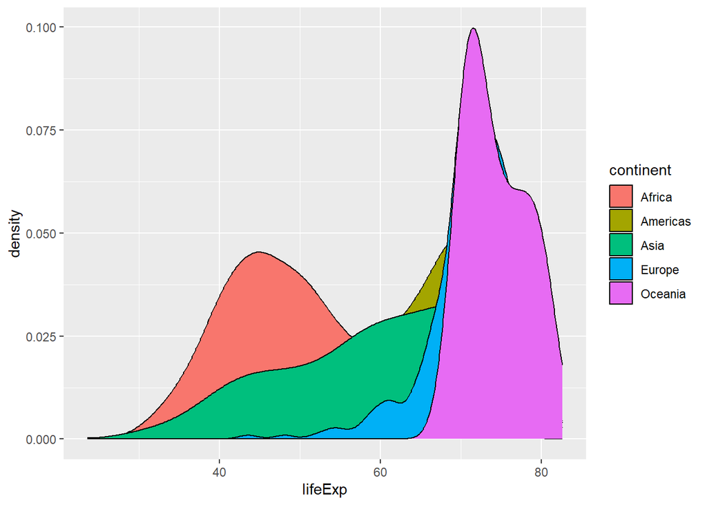

```r
ggplot(data = gapminder, aes(x = lifeExp, fill = continent)) +
  geom_density()
```

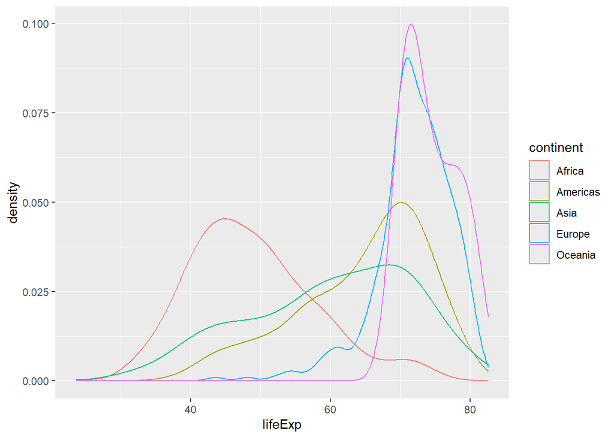

```r
ggplot(data = gapminder, aes(x = lifeExp, color = continent)) +
  geom_density()
```

### Q16. With geom_density and fill, experiment with different alpha’s.

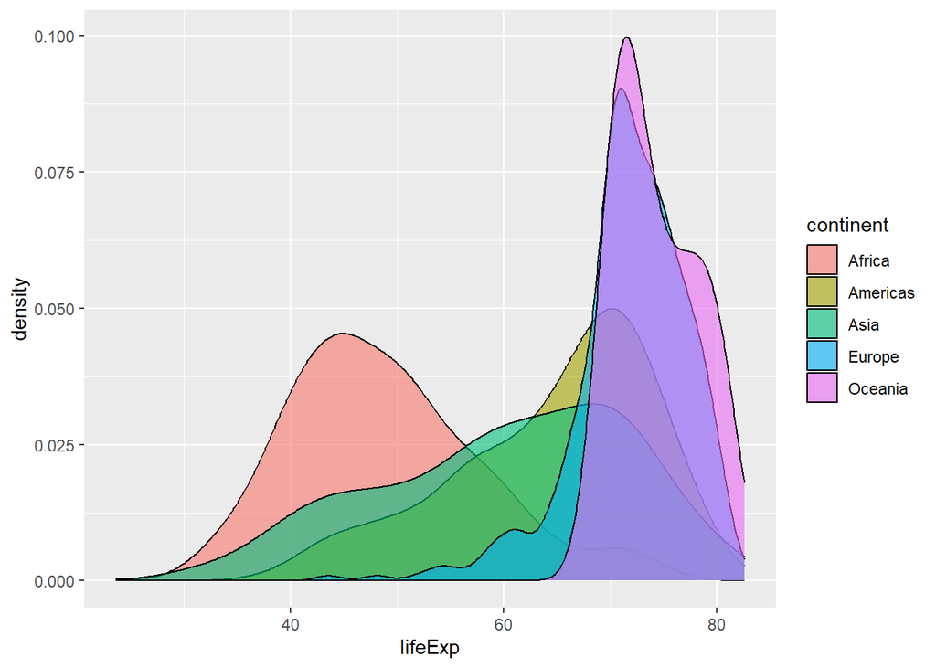

```r
ggplot(data = gapminder, aes(x = lifeExp, fill = continent)) +
  geom_density(alpha = 0.6)
```

### Q17. Add a vertical line to this plot.

Hint: for a vertical line, you’ll need to specify an x-intercept (and for a horizontal line, you’d need to specify a y-intercept). Do this with ‘xintercept = 70’.

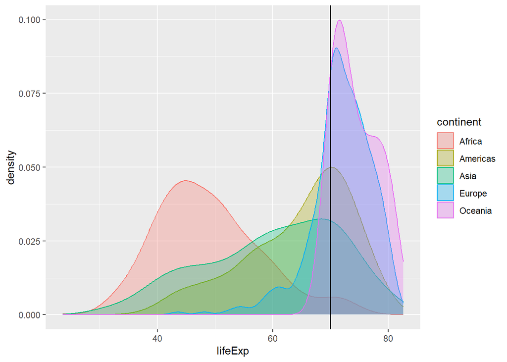

```r
ggplot(
  data = gapminder,
  aes(x = lifeExp, color = continent, fill = continent)
  ) +
  geom_density(alpha = .3) +
  geom_vline(xintercept = 70)
```

### Q18. Include the vertical line you did above, and also note how the annotation (‘annotate()’) labels the line.

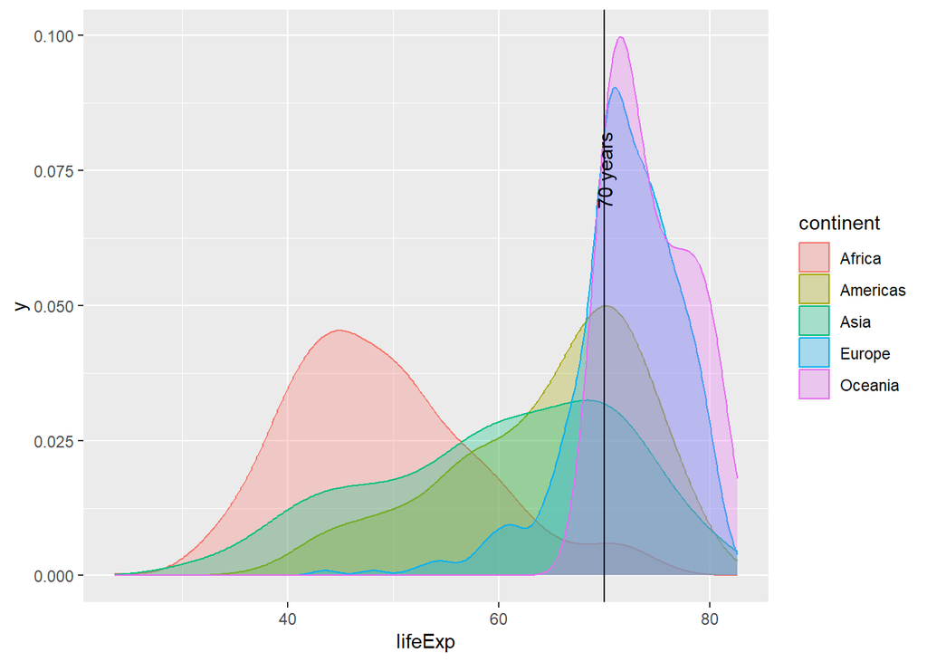

```r
ggplot(
  data = gapminder,
  aes(x = lifeExp, color = continent, fill = continent)
  ) +
  geom_density(alpha = .3) +
  geom_vline(xintercept = 70) +
  annotate(
    "text", x = 70, y = .075, label = "70 years", angle = 90
    )
```

### Q19. We’ve already talked about basic scatterplots. Try to recall how to draw a ggplot that plots ‘gdpPercap’ on the x-axis and ‘lifeExp’ on the y-axis.

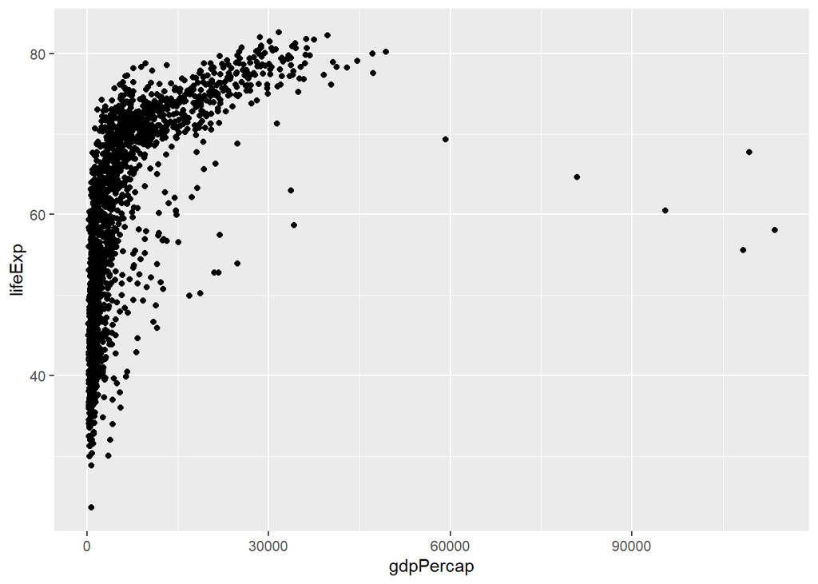

```r
ggplot(
  data = gapminder,
  aes(x = gdpPercap, y = lifeExp)
  ) +
  geom_point()
```

### Q20. Add a smoothed line layer to the plot you did above using geom_smooth().

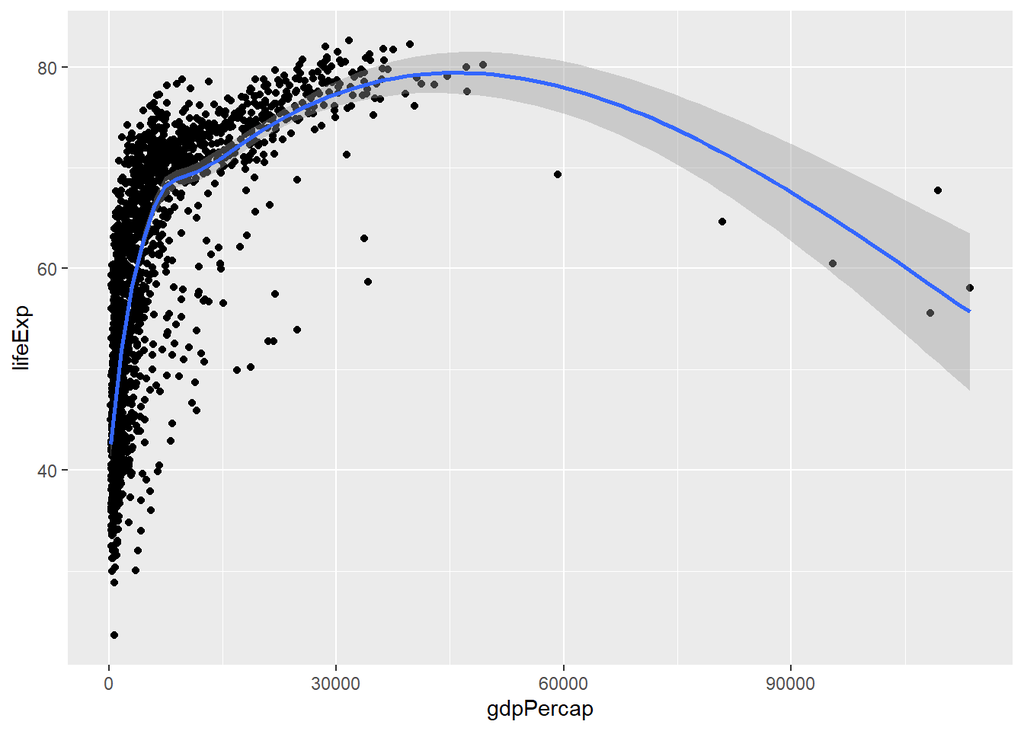

```r
ggplot(
  data = gapminder,
  aes(x = gdpPercap, y = lifeExp)
  ) +
  geom_point() +
  geom_smooth()
```

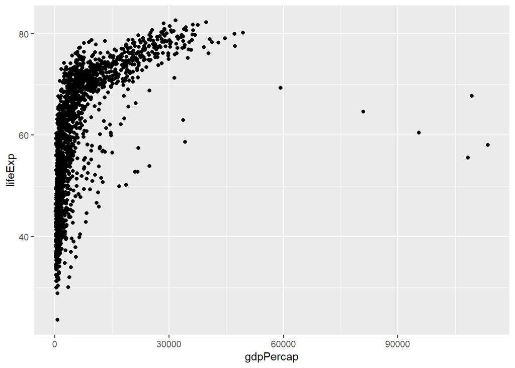

```r
ggplot(
  data = gapminder,
  aes(x = gdpPercap, y = lifeExp)
  ) +
  geom_point(se = FALSE)
```

### Q22. Visualize the OLS fit by using geom_smooth(method = “lm”).

“lm” stands for “linear model”.

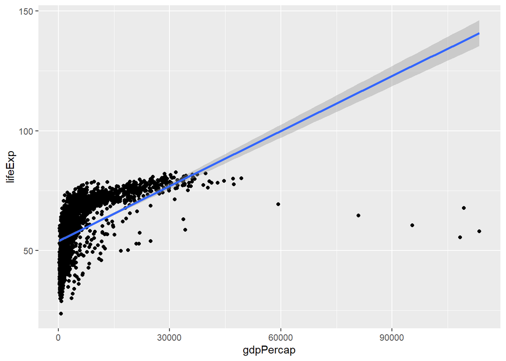

```r
ggplot(
  data = gapminder,
  aes(x = gdpPercap, y = lifeExp)
  ) +
  geom_point() +
  geom_smooth(method = "lm")
```

### Q23. Instead of plotting ‘gdpPercap’ on the x-axis, plot the log of ‘gdpPercap’ using log().

You should find that a linear model seems to fit this transformation much better.

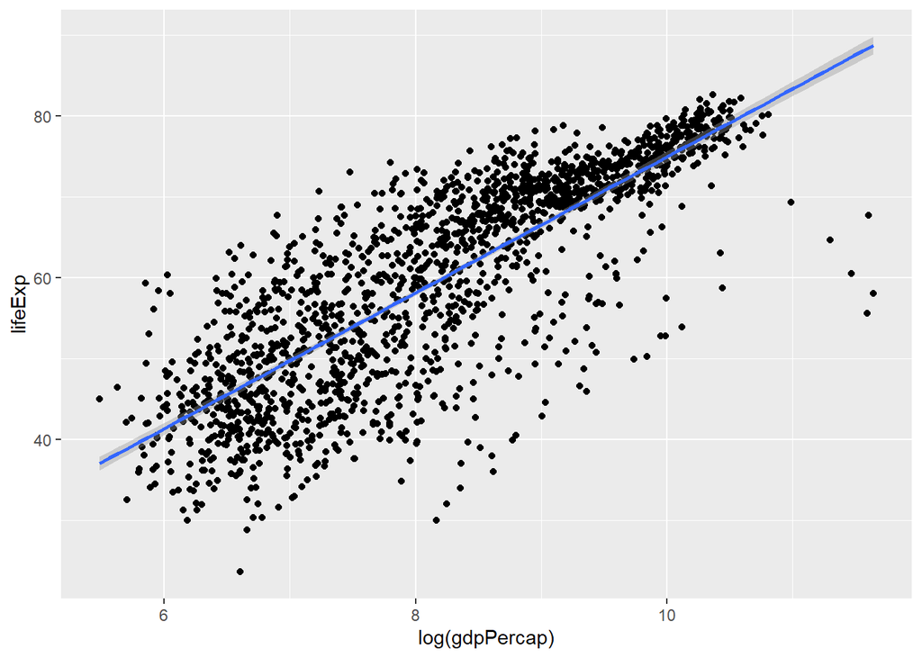

```r
ggplot(data = gapminder, aes(x = log(gdpPercap), y = lifeExp)) +
  geom_point() +
  geom_smooth(method = "lm")
```

Notice that the units on the x-axis of the previous plot are in log terms, which is hard to interpret. I prefer this method: Do a log transformation of the x-axis using ‘scale_x_log10()’, and use ‘labels = scales::comma’ to suppress scientific notation on the labels for the x-axis.

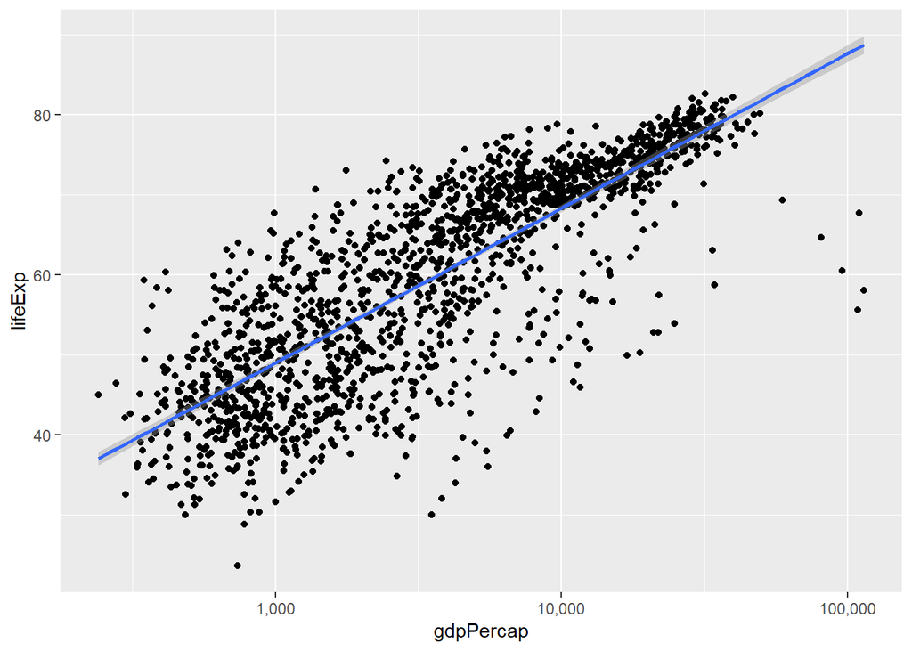

```r
ggplot(data = gapminder, aes(x = gdpPercap, y = lifeExp)) +
  scale_x_log10(labels = scales::comma) +
  geom_point() +
  geom_smooth(method = "lm")
```

### Q24. The second issue is that there’s over-plotting near the center.

I’d like a way to visualize how dense the points are getting. For this, we can replace ‘geom_point()’ with ‘geom_hex()’.

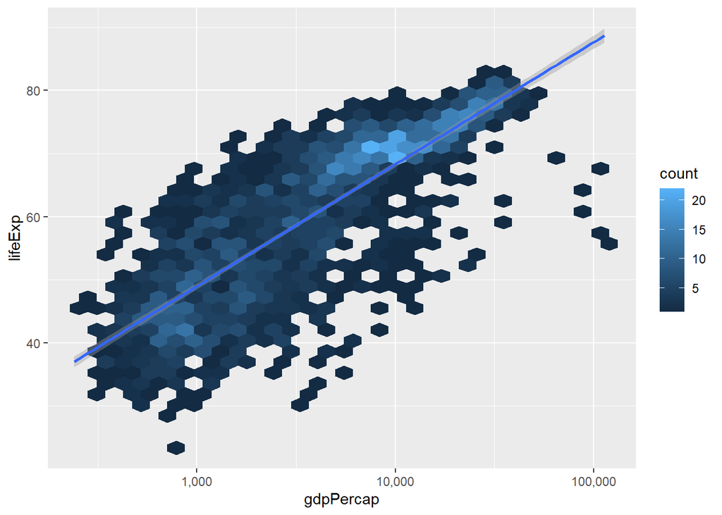

```r
ggplot(data = gapminder, aes(x = gdpPercap, y = lifeExp)) +
  scale_x_log10(labels = scales::comma) +
  geom_hex() +
  geom_smooth(method = "lm")
```

### Q25. Draw a line plot using ‘geom_line’. Compare US ‘gdpPercap’ over time to two other countries of your choice.

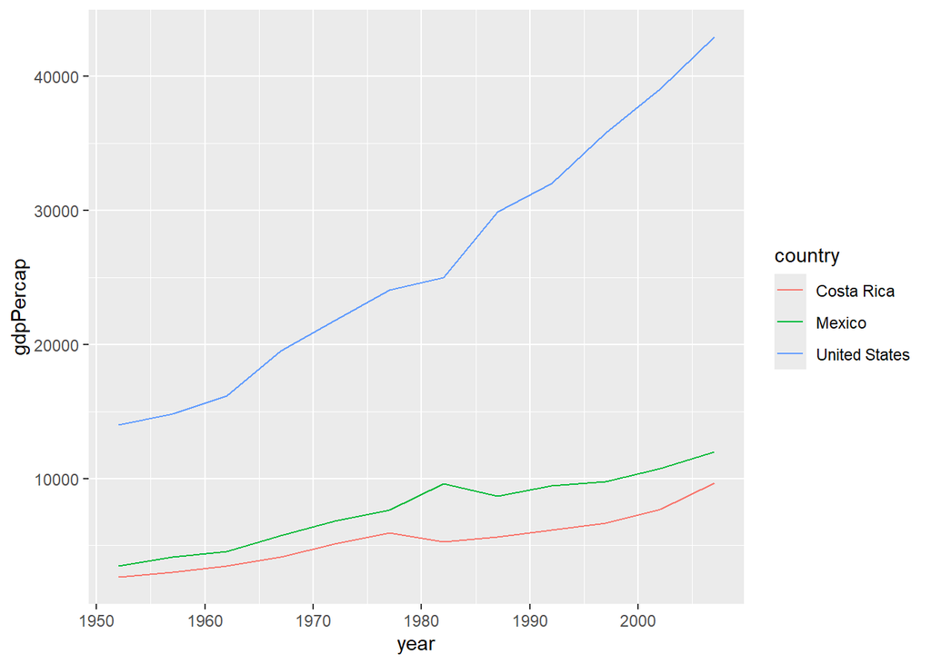

```r
gapminder %>%
  filter(country %in% c("United States", "Costa Rica", "Mexico")) %>%
  ggplot(aes(x = year, y = gdpPercap, color = country)) +
  geom_line()
```

### Q26. Draw a boxplot with geom_boxplot() that compares the gdpPercap (on the y-axis) of different continents (on the x-axis, also using color).

Experiment with applying a log transformation to gdpPercap (now on the y axis).

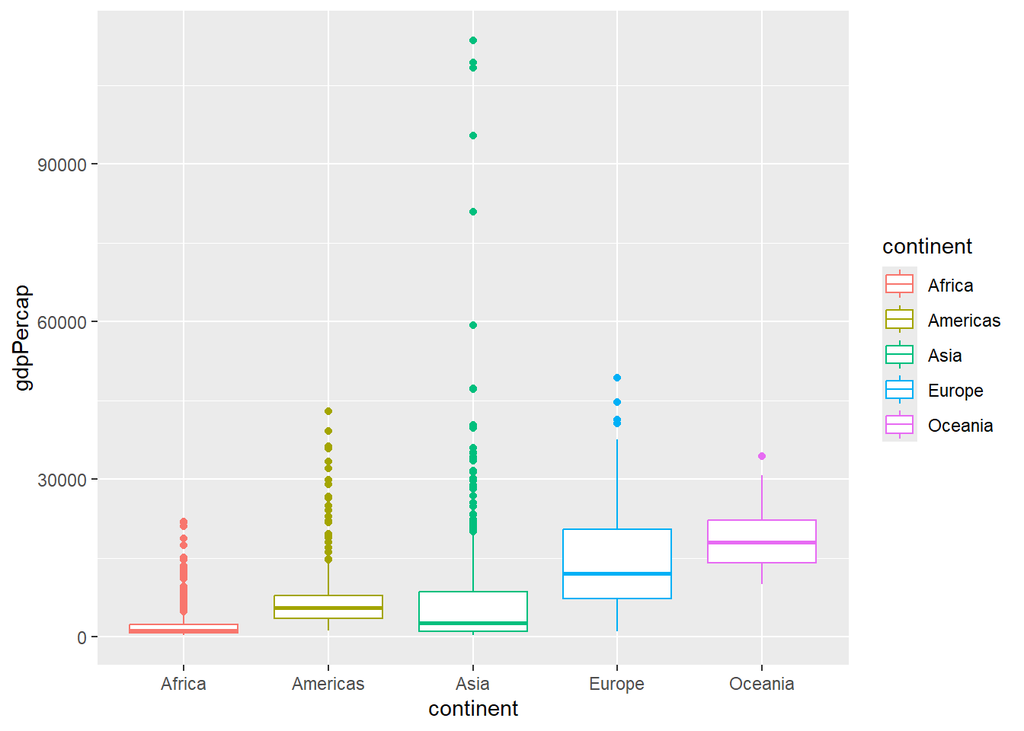

```r
ggplot(
  data = gapminder,
  aes(x = continent, y = gdpPercap, color = continent)
  ) +
  geom_boxplot()
```

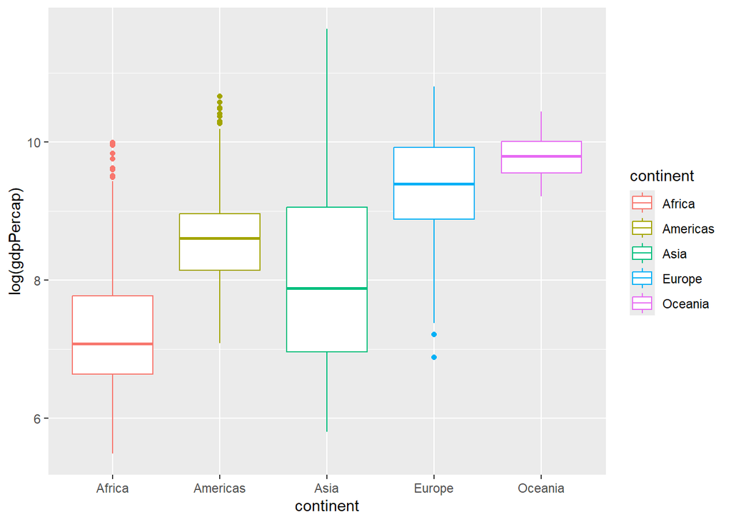

```r
ggplot(
  data = gapminder,
  aes(x = continent, y = log(gdpPercap), color = continent)
  ) +
  geom_boxplot()
```

### Q27. Change the plot from the previous question to be a violin plot using ‘geom_violin’.

Also include ‘fill’. Make sure you use ‘scale_y_log10()’ to transform the y-axis into log terms.

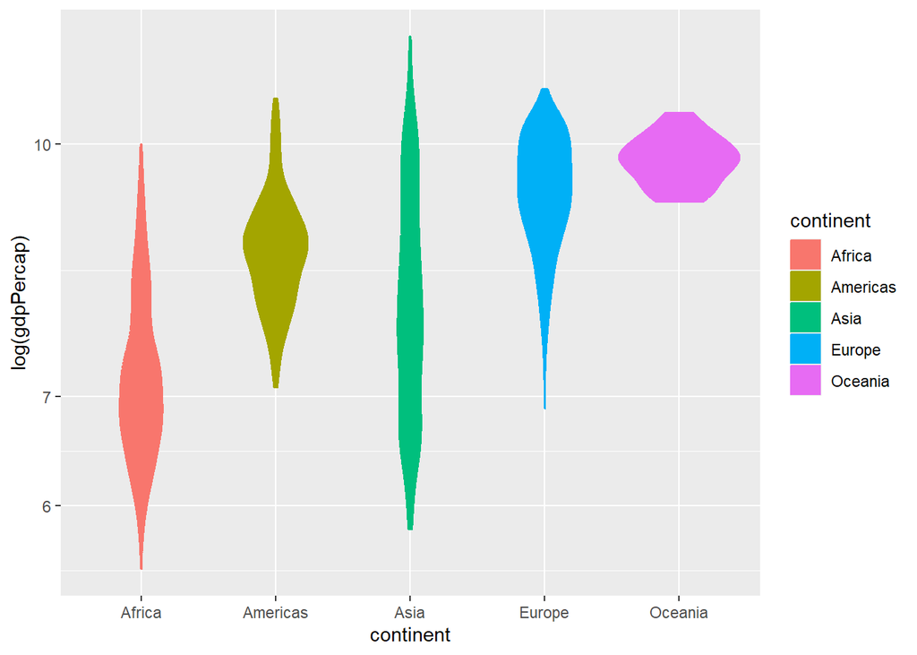

```r
ggplot(
  data = gapminder,
  aes(x = continent, y = log(gdpPercap), color = continent, fill = continent)
  ) +
  scale_y_log10() +
  geom_violin()
```

The ‘facet_wrap’ version:

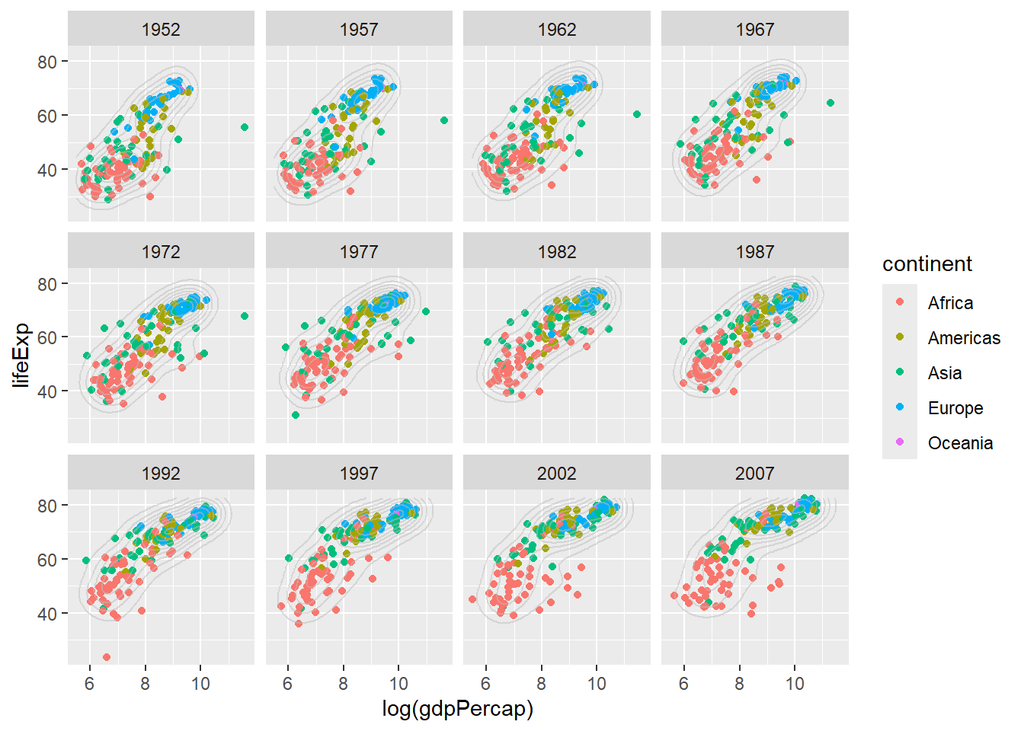

```r
ggplot(
  data = gapminder,
  aes(x = log(gdpPercap), y = lifeExp)
) +
  geom_point(aes(color = continent)) +
  geom_density2d(color = "grey", alpha = .5) +
  facet_wrap(~ year)
```